# DATA WRANGLING: HOW TO KNOCK IT OUT OF THE PARK

Cameron Jester

03/15/2022

```r
library(tidyverse)
library(ggplot2)
library(dplyr)
library(Lahman)
library(ggthemes)
```

# Welcome

Hello! Welcome to my tutorial on Data Wrangling! Data Wrangling is an important skill to have when working with large data sets. This will allow you to work more closely with the data you really *need*, as often times you will not need all of the data provided in a data set. Additionally, Data Wrangling can help your work become more reproducible because those trying to recreate your work will not get confused with data that was unused.

To demonstrate the various ways data can be wrangled I will be using the ‘Lahman’ package. The Lahman package includes various Major League Baseball data sets and was last updated in 2020.

[figure not shown]

Major League Baseball Logo. Source: New York Times

# Let’s Dive in

Today, I’m especially curious as to which players have played the most games at each postion in the MLB. Thankfully, the “Appearances” data set in the Lahman package can help us figure that out!

The first step when working with any data set is to do an exploratory analysis to get a good look at the data as a whole.

```r
Appearances = Lahman::Appearances

Appearances %>%
  sample_n(5)
```

```
##   yearID teamID lgID  playerID G_all GS G_batting G_defense G_p G_c G_1b G_2b
## 1   1953    CIN   NL kellybo01    28  5        28        28  28   0    0    0
## 2   2014    SEA   AL eliasro01    29 29         2        29  29   0    0    0
## 3   1971    SDN   NL  deanto01    41 21        41        39   0   0    0    1
## 4   1997    TOR   AL clemero02    34 34         1        34  34   0    0    0
## 5   1976    SFN   NL clarkja01    26 26        26        26   0   0    0    0
##   G_3b G_ss G_lf G_cf G_rf G_of G_dh G_ph G_pr
## 1    0    0    0    0    0    0    0    0    0
## 2    0    0    0    0    0    0    0    0    0
## 3   11   28    0    0    0    0    0    2    2
## 4    0    0    0    0    0    0    0    0    0
## 5    0    0    4   20    8   26    0    0    0
```

The Appearances data set includes the name, team, year, and position played for 108,717 players in the MLB from 1871 - 2020. For your viewing convenience, I have selected a random sample of 5 rows using the ‘sample_n()’ function from the dplyr package.

To find out which players have played the most games at each position, we will need to extract the ‘yearID’, ‘playerID’, and ‘G_c’ through ‘G_rf’ variables to work with more closely. To do this, we will use the ‘select()’ function, which will *select* the variables outlined above.

Additionally, at this step it might be helpful to rename our columns for readability. We will use the ‘rename()’ function to *rename* each column to something more readable, for example ’G_lf" should be turned into “LF”, which is easier to identify as Left Fielder!

```r
 Appear_top = Appearances %>%
    select(playerID, G_p:G_rf, yearID) %>%
    rename(P = G_p,C = G_c, `1B` = G_1b, `2B` = G_2b, SS = G_ss,
           `3B` = G_3b, LF = G_lf, CF = G_cf, RF = G_rf)

Appear_top %>%
  sample_n(5)
```

```
##    playerID  P   C 1B 2B 3B SS LF CF RF yearID
## 1 hastisc01  0  19  0  1  0  0  0 12  0   1873
## 2 johnsch04  0 123  0  0  0  0  0  0  0   1997
## 3 lasteto01  0   0  3 46 30  0  0  0  0   2019
## 4 leiteal01 33   0  0  0  0  0  0  0  0   1996
## 5 smithke01  0   0  0  0  0  0  4  1  2   1980
```

Using this random sample of 5 rows to assess how our columns look now, I’d say we’re in pretty good shape. I think we’re ready to go to the next step in our data!

## Deeper Dive

To figure out which players (‘playerID’) played the most games at each position (‘pos’), we have to *group* the data by both of those variables to conduct the appropriate analysis. This is done by the ‘group_by()’ function!

Now that we have grouped the data by position and player, we are ready to calculate the number of games each player played at each position. To do that we will use the ‘summarize()’ function to get a *summary* of the statistic we are calculating, which in this case is the sum of games.

Right now we are in great shape! I think we are ready to move to the final step of data wrangling. Now we are going to *arrange* the data from most games to least games at each position. Thankfully, functions in R, if you haven’t noticed functions are named to reflect their purpose, so to arrange we will use the ‘arrange()’ function. Finally, since there are 9 positions in baseball, we want to extract the top number of games, and the name of the player for each position, so we will use the ‘head()’ function to do this!

```r
 Appear_top = Appearances %>%
    select(playerID, G_p:G_rf, yearID) %>%
    rename(P = G_p, C = G_c, `1B` = G_1b, `2B` = G_2b, SS = G_ss,`3B` = G_3b, LF = G_lf, CF = G_cf, RF = G_rf) %>%
    pivot_longer(names_to = 'pos' ,values_to = 'G', P:RF) %>%
    group_by(pos, playerID) %>%
    summarize ( G = sum(G)) %>%
    arrange(desc(G)) %>%
    do(head(., 1))
```

[output not shown]

```r
Appear_top
```

```
## # A tibble: 9 × 3
## # Groups:   pos [9]
##   pos   playerID      G
##   <chr> <chr>     <int>
## 1 1B    murraed02  2413
## 2 2B    collied01  2648
## 3 3B    robinbr01  2870
## 4 C     rodriiv01  2427
## 5 CF    mayswi01   2829
## 6 LF    bondsba01  2715
## 7 P     oroscje01  1252
## 8 RF    clemero01  2305
## 9 SS    vizquom01  2709
```

Great! Now we have a table that shows us the name of the player who played the highest number of games for each position. This is pretty neat information and we were able to get this all by performing a bit of data wrangling on our original data set.

## Anything Else?

Come to think of it… I am curious about one additional thing. I want to know if any of the players in the table above got into the Baseball Hall of Fame. Thankfully, the Lahman package also includes a data set called ‘HOF’ that has information on all of the players who have (or haven’t) been inducted.

To get the information we need into one neat table, we will want to *join* together these two data sets. To do this we will begin with “Appear_top” and use the ‘full_join()’ function to append the “HOF” data to the table we made in the last step. Because we want to know if specific players have gotten inducted, we will join the tables together by ‘playerID’.

```r
HOF_join = Appear_top %>%
  full_join(HOF, by = "playerID")

HOF_join
```

```
## # A tibble: 4,191 × 5
## # Groups:   pos [10]
##    pos   playerID      G yearID inducted
##    <chr> <chr>     <int>  <int> <fct>
##  1 1B    murraed02  2413   2003 Y
##  2 2B    collied01  2648   1936 N
##  3 2B    collied01  2648   1937 N
##  4 2B    collied01  2648   1938 N
##  5 2B    collied01  2648   1939 Y
##  6 3B    robinbr01  2870   1983 Y
##  7 C     rodriiv01  2427   2017 Y
##  8 CF    mayswi01   2829   1979 Y
##  9 LF    bondsba01  2715   2013 N
## 10 LF    bondsba01  2715   2014 N
## # … with 4,181 more rows
```

This table is much larger than our previous table, because we already know the ‘playerID’ we are looking for to see if there have been inducted, we will use the ‘filter()’ function to filter for the names of the players we are looking for. Because a few of these players have been nominated for the Hall of Fame a few separate times, we want to *filter* for year, so we only see the most recent year they were nominated (and didn’t get in) or were nominated and got inducted!

One last step is to once again *arrange* the data from the most number games to least number of games. To do that, we are going to use the arrange function once more.

```r
HOF_join_filter = HOF_join %>%
  filter(playerID %in% c( "collied01", "robinbr01", "mayswi01", "murraed02", "bondsba01", "vizquom01","rodriiv01", "oroscje01", "clemero01"))%>%
  filter (yearID %in% c("2003", "1939", "1983", "2017", "1979", "2018", "1973", "2009")) %>%
  arrange(desc(G))

HOF_join_filter
```

```
## # A tibble: 10 × 5
## # Groups:   pos [9]
##    pos   playerID      G yearID inducted
##    <chr> <chr>     <int>  <int> <fct>
##  1 3B    robinbr01  2870   1983 Y
##  2 CF    mayswi01   2829   1979 Y
##  3 LF    bondsba01  2715   2017 N
##  4 LF    bondsba01  2715   2018 N
##  5 SS    vizquom01  2709   2018 N
##  6 2B    collied01  2648   1939 Y
##  7 C     rodriiv01  2427   2017 Y
##  8 1B    murraed02  2413   2003 Y
##  9 RF    clemero01  2305   1973 Y
## 10 P     oroscje01  1252   2009 N
```

There you have it! A table with the most number of games played by a player at all 9 positions in baseball and if the player holding that title got inducted into the Hall of Fame. With the help of data wrangling, we were able to take two very comprehensive sets of data and create a condensed, and meaningful subset of data that can be easily read by anyone, baseball fan or not.

**Side Note** You may be curious as to why Barry Bonds appears more than once in our final data set, well..that’s a story for another time!

## Let’s Visualize

An important part of any data analysis is to create an informative visual to go along with any tables you may have created. Using the ggplot() function, we can create a bar graph to separate players who have or have not gotten into the HOF.

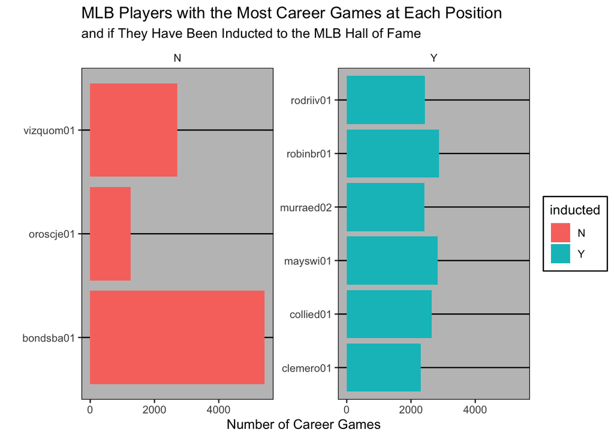

```r
HOF_join_filter %>%
  ggplot(aes(x = playerID, y = G, fill = inducted)) + geom_col() + facet_wrap(~inducted, scales = "free_y") + coord_flip() + theme_excel() + labs ( y = "Number of Career Games ", x = "", title = "MLB Players with the Most Career Games at Each Position ", subtitle = "and if They Have Been Inducted to the MLB Hall of Fame")
```